# Import libraries

```python
import pandas as pd
import matplotlib.pyplot as plt
```

# Import dataset

```python
df=pd.read_excel('C:\\Users\\arpit\\Downloads\\Fuel_Data_(Rev.01-25-Feb-20).xlsx')
print(df)
```

```
      EMPLOYEE           XSATRANDAT        VEHICLE       PTROCRD   EXPAMT  \
0     23149398  2019-05-02 00:00:00  KA 03 MU 1683  FC0013800270  2134.35
1     23149398  2019-05-09 00:00:00  KA 03 MU 1683  FC0013800270  3715.10
2     23149398  2019-07-02 00:00:00  KA 03 MU 1683  FC0013800270  3992.79
3     23149398  2019-07-19 00:00:00  KA 03 MU 1683  FC0013800270  4314.24
4     23149398  2019-08-02 00:00:00  KA 03 MU 1683  FC0013800270  4507.80
...        ...                  ...            ...           ...      ...
1949  23100962  2019-07-30 00:00:00     WB02AD7306  FC0013800312  4229.64
1950  23100962  9999-12-31 00:00:00     WB02AD7306  FC0013800312  1366.20
1951  25005101  2019-10-05 00:00:00  WB-02-AD-7306  FC0013800312  4467.25
1952  25005101  9999-12-31 00:00:00  WB-02-AD-7306  FC0013800312  4467.25
1953  23100962  2019-12-09 00:00:00  WB-20-BE-7622  FC0013800312  4696.34

     TRANTYP                         CNAME    DELCITY  AU_MOTOR  ODOMETR
0     DIESEL  INDIA GARAGE SERVICE STATION  Bangalore     31.00    17937
1     DIESEL             BENAKA ENTERPRISE  Bangalore     54.03    18590
2     DIESEL  INDIA GARAGE SERVICE STATION  Bangalore     60.06    19913
3     DIESEL  INDIA GARAGE SERVICE STATION  Bangalore     63.00    20535
4     DIESEL  INDIA GARAGE SERVICE STATION  Bangalore     66.00    21190
...      ...                           ...        ...       ...      ...
1949  DIESEL            SHYAMA TRADING CO.    Kolkata     62.00    62642
1950  DIESEL         MILAP SERVICE STATION    Kolkata     20.00    60808
1951  DIESEL                         CAMAC    Kolkata     64.24    63928
1952  DIESEL                         CAMAC    Kolkata     64.24    63928
1953  DIESEL                         CAMAC    Kolkata     68.66      898

[1954 rows x 10 columns]
```

# Identification of variable:-Here we could see that we have both continuous and categorical variable which contains int and object type data.

# Identification of datatype

```python
print(df.dtypes)
```

```
EMPLOYEE        int64
XSATRANDAT     object
VEHICLE        object
PTROCRD        object
EXPAMT        float64
TRANTYP        object
CNAME          object
DELCITY        object
AU_MOTOR      float64
ODOMETR         int64
dtype: object
```

# Identification of size

```python
print(df.shape)
```

```
(1954, 10)
```

# Identification of stats

```python
print(df.describe())
```

```
           EMPLOYEE       EXPAMT     AU_MOTOR       ODOMETR
count  1.954000e+03  1954.000000  1954.000000  1.954000e+03
mean   1.111929e+07  3200.922364    44.661192  4.097083e+04
std    1.154024e+07   979.997139    14.254718  2.215560e+05
min    2.000250e+05     1.000000     0.000000  0.000000e+00
25%    2.061740e+05  2526.895000    34.837500  1.011200e+04
50%    2.146120e+05  3158.760000    44.300000  2.810200e+04
75%    2.316216e+07  3964.125000    56.000000  5.119125e+04
max    2.500510e+07  5000.000000    75.300000  9.627123e+06
```

# Find out the missing value in the dataset according to column wise

```python
print(df.apply(lambda x: sum(x.isnull()),axis=0))
```

```
EMPLOYEE      0
XSATRANDAT    0
VEHICLE       0
PTROCRD       0
EXPAMT        0
TRANTYP       1
CNAME         0
DELCITY       0
AU_MOTOR      0
ODOMETR       0
dtype: int64
```

# Variable 1:-EMPLOYEE

```python
print(df['EMPLOYEE'].unique())
print(df['EMPLOYEE'].nunique())
```

```
[23149398   200256   210462 23061454 23182426   500176 23192481 23061475
   204911 24009256 23061154 23141621 23144253   211197   208607   204364
 23098768   206055   201273 23079920 23010021   214059   214830   209397
   215667   200720   209218   200519   206814 23137327   208989   205045
   210613   203213   200025   210379   207967   206923   204132   214612
   200785 23144970   207307 23151702 23135551   206174 23148131   208369
 23155311 23102980   205131   200577   215401 23162160   209105   214609
   200238   203656   201661 23163907 23166093   203380   202214 23166736
   200755   208071 23167435 23076582   211002   203610 23167137   210401
   209479 23172291   200895 23075752   201508   212834 23192841 23073922
 23200122 23103492   213593 23082897 23172838 25000431 23103379 23106941
 25001212 23061155 25001858   208492   215250 23010044   206575   214614
   208891   210103 23092538 23066772 23062237 23061476 25000421 25001145
 25001262 23096645   204912   212752 23100962 25005101]
110
```

# Find the total count of each data_item using value_count()

```python
print(df['EMPLOYEE'].value_counts())
```

```
23192481    283
206055       83
200720       78
23141621     52
206814       41
           ...
207967        1
23182426      1
23167435      1
23061154      1
210401        1
Name: EMPLOYEE, Length: 110, dtype: int64
```

# Plotting of graph using bar graph:- As we know that bar graph is generally used for comparision of two category in a particular column but if we have continuous variable then we use to take the top 5 or 10 data_items because as we know that we if we plot all the data_item then in graph all the data_item will appear close to each other due to which analysis of data is not done properly and bars will overlap with each other and due to which we will not able to analyze the total count of any data_item and hence anlaysis will not be done clearly with bar graph for continuous variable and object type if column contains more data.

```
<BarContainer object of 6 artists>
```

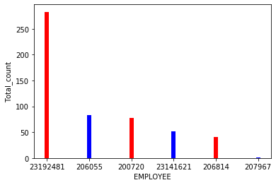

```python
x=["23192481","206055","200720","23141621","206814","207967"]
y=[283,83,78,52,41,1]
plt.xlabel('EMPLOYEE')
plt.ylabel('Total_count')
plt.bar(x,y,width =0.1,color =['red','blue'])
```

# Variable 2:-Date and Time

```python
print(df['XSATRANDAT'].unique())
print(df['XSATRANDAT'].nunique())
```

[output not shown]

[output cut: 55 more lines]

```
 datetime.datetime(2019, 12, 31, 0, 0)
 datetime.datetime(2019, 12, 3, 0, 0) datetime.datetime(2019, 10, 6, 0, 0)
 datetime.datetime(2019, 12, 5, 0, 0)
 datetime.datetime(2019, 12, 18, 0, 0)
 datetime.datetime(2019, 12, 23, 0, 0)
 datetime.datetime(2019, 10, 27, 0, 0)
 datetime.datetime(2019, 12, 21, 0, 0)
 datetime.datetime(2019, 10, 11, 0, 0)
 datetime.datetime(2019, 12, 13, 0, 0)
 datetime.datetime(2019, 12, 8, 0, 0)
 datetime.datetime(2019, 12, 28, 0, 0)
 datetime.datetime(2019, 10, 26, 0, 0)
 datetime.datetime(2019, 10, 8, 0, 0)
 datetime.datetime(2019, 12, 22, 0, 0)]
162
```

# Find the total count of each data_item using value_count()

```python
print(df['XSATRANDAT'].value_counts())
```

```
9999-12-31 00:00:00    344
2019-07-15 00:00:00     21
2019-08-07 00:00:00     19
2019-08-31 00:00:00     17
2019-07-01 00:00:00     17
                      ...
2019-07-14 00:00:00      3
2019-01-17 00:00:00      2
2019-12-22 00:00:00      2
2019-01-16 00:00:00      1
2019-01-14 00:00:00      1
Name: XSATRANDAT, Length: 162, dtype: int64
```

# Plotting of graph using bar graph:-As we know that bar graph is generally used for comparision of two category in a particular column but if we have object datatype then we use to take the top 5 or 10 data_items because as we know that we if we plot all the data_item then in graph all the data_item will appear close to each other due to which analysis of data is not done properly and bars will overlap with each other and due to which we will not able to analyze the total count of any data_item and hence anlaysis will not be done clearly with bar graph for continuous variable and object type if column contains more data.

```
<BarContainer object of 5 artists>
```

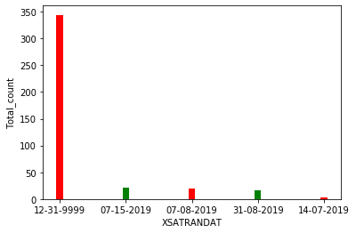

```python
x=["12-31-9999","07-15-2019","07-08-2019","31-08-2019","14-07-2019"]
y=[344,21,19,17,3]
plt.xlabel('XSATRANDAT')
plt.ylabel('Total_count')
plt.bar(x,y,width =0.1,color =['red','green'])
```

# Variable 3:-VEHICLE

```python
print(df['VEHICLE'].unique())
print(df['VEHICLE'].nunique())
```

```
['KA 03 MU 1683' 'KA 04 MQ 6924' 'KA-01-MQ-6924' 'KA-03-MU-1683'
 'KCMET DEPT' 'KL 07 BY 9244' 'KL 07 CM 7452' 'KL-07-CM-7452'
 'MH 01 AH 9059' 'MH 01 AL 2011' 'MH 01 AL 2891' 'MH 01 AX6934'
 'MH 01 BB 1472' 'MH 01 BB 1603' 'MH 01 BB 5087' 'MH 01 BF 0689'
 'MH 01 BF 1950' 'MH 01 BF 3607' 'MH 01 BF 4289' 'MH 01 BF 5901'
 'MH 01 BF 7223' 'MH 01 BF 7282' 'MH 01 BG 1270' 'MH 01 BG 8276'
 'MH 01 BG 8823' 'MH 01 BK 0589' 'MH 01 BK 4088' 'MH 01 BK 5373'
 'MH 01 BK 6806' 'MH 01 BK 7437' 'MH 01 BK 7728' 'MH 01 BK 7995'
 'MH 01 BK 8101' 'MH 01 BK 9809' 'MH 01 BR 1555' 'MH 01 BS 1555'
 'MH 01 BU 1446' 'MH 01 BU 2759' 'MH 01 BU 3361' 'MH 01 BU 4372'
 'MH 01 BU 4808' 'MH 01 BU 7413' 'MH 01 BU 8057' 'MH 01 BU 8819'
 'MH 01 BY 0867' 'MH 01 BY 0998' 'MH 01 BY 1003' 'MH 01 BY 1753'
 'MH 01 BY 3568' 'MH 01 BY 6408' 'MH 01 BY 6965' 'MH 01 BY 7044'
 'MH 01 BY 7839' 'MH 01 BY 8298' 'MH 01 BY 8551' 'MH 01 BY 8717'
 'MH 01 BY 9802' 'MH 01 CD 0424' 'MH 01 CD 0425' 'MH 01 CD 1017'
 'MH 01 CD 1907' 'MH 01 CD 2161' 'MH 01 CD 2509' 'MH 01 CD 2663'
 'MH 01 CD 2665' 'MH 01 CD 2869' 'MH 01 CD 3498' 'MH 01 CD 4928'
 'MH 01 CD 4929' 'MH 01 CD 5338' 'MH 01 CD 5475' 'MH 01 CD 5766'
 'MH 01 CD 5816' 'MH 01 CD 5877' 'MH 01 CD 5914' 'MH 01 CD 5986'
 'MH 01 CD 6173' 'MH 01 CD 6615' 'MH 01 CD 6968' 'MH 01 CD 6972'
 'MH 01 CD 6991' 'MH 01 CD 7461' 'MH 01 CD 7620' 'MH 01 CD 8376'
 'MH 01 CD 8678' 'MH 01 CD 8722' 'MH 01 CD 9361' 'MH 01 CD 9439'
 'MH 01 CD 9760' 'MH 01 CH 0424' 'MH 01 CH 0442' 'MH 01 CH 1171'
 'MH 01 CH 1340' 'MH 01 CH 1772' 'MH 01 CH 2138' 'MH 01 CH 3597'
 'MH 01 CH 3603' 'MH 01 CH 3956' 'MH 01 CH 5732' 'MH 01 CH 6138'
 'MH 01 CP 2491' 'MH 01 CP 4029' 'MH 01 CP 4853' 'MH 01 CP 5057'
 'MH 01 CP 7882' 'MH 01 CP 9491' 'MH 01 CQ 1323' 'MH 01 CQ 5677'
 'MH 01 CT  7460' 'MH 01 CT 0748' 'MH 01 CT 3496' 'MH 01 CT 7133'
 'MH 01 CT 8311' 'MH 01 DB 1183' 'MH 01 DB 1288' 'MH 01 DB 3182'
 'MH 01 DB 3288' 'MH 01 DB 3655' 'MH 01 DB 3814' 'Mh 01 DB 3984'
 'MH 01 DB 5178' 'MH 01 DB 5803' 'MH 01 DB 6686' 'MH 01 DB 6965'
 'MH 01 DB 7214' 'MH 01 DB 7561' 'MH 01 DB 9261' 'MH 01 DB 9362'
 'MH 01 DE 2254' 'MH 01 DE 4602' 'MH 01 DE 6997' 'MH 01 DE 7303'
 'MH 01 DE 7942' 'MH 01 DE 8851' 'MH 01 DE 8932' 'MH 01 DK 0812'
 'MH 01CP 2422' 'MH 1 CH 0424' 'MH 14 CK 2660' 'MH 14 CS 9823'
 'MH 14 EC 1370' 'MH 14 FM 2784' 'MH 15 DC 2387' 'MH 15 DS 8327'
 'MH 15 DS 8356' 'MH 15 EP 1635' 'MH 15 EX 4733' 'MH 15 FT 4366'
 'MH 47 AF 1555' 'MH01 CH 5421' 'MH-01-AL-2011' 'MH01AL2891'
 'MH-01-AX-6934' 'MH-01-BB-1472' 'MH-01-BF-1950' 'MH-01-BF-4289'
 'MH01BF5901' 'MH-01-BF-5901' 'MH01BG1270' 'MH-01-BG-1270' 'MH01BK0613'
```

[output cut: 22 more lines]

```
 'MH-01-DB-7561' 'MH01DB9230' 'MH-01-DB-9230' 'MH01DB9238' 'MH-01-DB-9261'
 'MH-01-DB-9362' 'MH01DB9520' 'MH-01-DB-9520' 'MH01DB9579' 'MH-01-DB-9579'
 'MH-01-DE-1472' 'MH01DE2110' 'MH-01-DE-2110' 'MH-01-DE-2254'
 'MH-01-DE-2469' 'MH01DE3974' 'MH-01-DE-3974' 'MH01DE4125' 'MH-01-DE-4125'
 'MH-01-DE-4602' 'MH-01-DE-6997' 'MH-01-DE-7303' 'MH-01-DE-7942'
 'MH01DE8736' 'MH-01-DE-8736' 'MH-01-DE-8824' 'MH-01-DE-8851' 'MH01DE8932'
 'MH-01-DE-8932' 'MH01DH1555' 'MH-01-DH-1555' 'MH-01-DK-0812'
 'MH-01-DK-2079' 'MH-01-DK-2611' 'MH-01-DK-2686' 'MH-01-DK-3739'
 'MH-01-DK-4087' 'MH-03-CB-6188' 'MH-14-CK-2660' 'MH-14-CS-9823'
 'MH-14-FM-2784' 'MH-15-DC-2387' 'MH-15-DS-8327' 'Mh15EX4642'
 'MH-15-EX-4733' 'MH-15-FT-4366' 'MH47AF1555' 'MH-47-AF-1555'
 'MHO1 CD6750' 'POOL 0003' 'POOL 0004' 'POOL 0006' 'POOL 0008' 'POOL 0010'
 'POOL 0012' 'POOL 0014' 'POOL 0017' 'POOL 0019' 'POOL 0021' 'POOL 0022'
 'TN01BF4928' 'TN-01-BF-4982' 'WB02AD7306' 'WB-02-AD-7306' 'WB-20-BE-7622']
317
```

# Find the total count of each data_item using value_count()

```python
print(df['VEHICLE'].value_counts())
```

```
MH01DB9238       20
MH 01 CH 0442    20
MH 15 DC 2387    20
MH 15 EX 4733    20
MH 01 DB 5178    18
                 ..
MH 01 CD 5766     1
MH-01-BS-1555     1
MH 01 CD 6972     1
MH-01-BU-1446     1
MH 15 EP 1635     1
Name: VEHICLE, Length: 317, dtype: int64
```

# Plotting of graph using bar graph:-As we know that bar graph is generally used for comparision of two category in a particular column but if we have object datatype then we use to take the top 5 or 10 data_items because as we know that we if we plot all the data_item then in graph all the data_item will appear close to each other due to which analysis of data is not done properly and bars will overlap with each other and due to which we will not able to analyze the total count of any data_item and hence anlaysis will not be done clearly with bar graph for continuous variable and object type if column contains more data.

```
<BarContainer object of 3 artists>
```

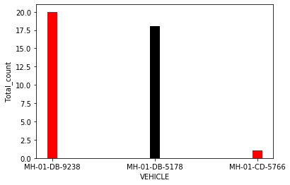

```python
x=["MH-01-DB-9238","MH-01-DB-5178","MH-01-CD-5766"]
y=[20,18,1]
plt.xlabel('VEHICLE')
plt.ylabel('Total_count')
plt.bar(x,y,width =0.1,color =['red','black'])
```

# Variable 4:-PTROCRD

```python
print(df['PTROCRD'].unique())
print(df['PTROCRD'].nunique())
```

[output not shown]

# Find the total count of each data_item using value_count()

```python
print(df['PTROCRD'].value_counts())
```

```
FC0005694954    33
FC0005695035    32
FC0005694277    30
FC0005694475    30
FC0005693980    29
                ..
FC7001458689     1
FC7001458787     1
FC7001458652     1
FC7001723977     1
FC7001458735     1
Name: PTROCRD, Length: 228, dtype: int64
```